# Estadísticas de Accidentes en Madrid

### José Agustín Ianchina Raed

### Enero 25, 2022

## Introducción

En este proyecto, se desarrolla un análisis básico de datos en Python sobre accidentes de tráfico de la Comunidad de Madrid. Los datos provienen del archivo provisto para realizar la tarea: 2020_Accidentalidad.csv. A partir de ellos, he realizado cada uno de los puntos siguiente la secuencia propuesta por el notebook. He conseguido realizar cada uno de los ejercicios y he resuelto las dificultades que he encontrado básicamente de internet. (Se citan las páginas en la sección de bibliografía)

## a) Algunas operaciones sencillas [2 puntos]

[figure not shown]

Si miramos una línea de esta tabla (salvo la primera, que es la cabecera), encontamos lo siguiente:

| 2020S000073 | 01/01/2020 | 18:48 | AVDA. PIO XII | 81 | CHAMARTÍN | Atropello a persona | Despejado | Turismo | Conductor | DE 55 A 59 AÑOS | Hombre | 14 |  |
| --- | --- | --- | --- | --- | --- | --- | --- | --- | --- | --- | --- | --- | --- |

Pero si inspeccionamos el archivo con un editor de texto, vemos que esa línea es como sigue:

```
2020S000073;01/01/2020;18:48;AVDA. PIO XII;81;CHAMARTÍN;Atropello a persona;Despejado;Turismo;Conductor;DE 55 A 59 AÑOS;Hombre;14;;
```

Una cadena de caracteres. Hagamos en Python algunas operaciones básicas con los algunos de los datos anteriores y con la cadena en sí.

**a.1 Redondeo de la hora**

La primera operación consiste en redondear una hora, simplemente despreciando los minutos y dando lugar al entero correspondiente, entre 0 y 23.

```python
# Esta celda debe ser completada por el estudiante
def redondeo_hora(a):
    """
    Given a string a which represents a time, it returns the hours integer.

    Parameters
    ----------
    a : string
        'hh:mm'

    Return
    ------
    integer
        The value which represents the hours of time given by a.

    Example
    -------
    >>> redondeo_hora('12:48')
    12
    """
    return int(a.split(':')[0])
```

```python
# Pruebas de funcionamiento:

print(redondeo_hora('12:48'))
```

```
12
```

Es bastante habitual hacer varias pruebas a la vez:

```python
# Pruebas de funcionamiento:

for h in ['15:00', '23:15', '14:22']:
    print(redondeo_hora(h))
```

```
15
23
14
```

**a.2 Rangos de edad**

Ahora, deseamos codificar los rangos de edad, asignando a cada rango descrito un intervalo de dos enteros. El ejemplo de funcionamiento te aclarará lo que se pide exactamente:

```python
# Esta celda debe ser completada por el estudiante
def rango_edad(rangos_edad):
    """
    Given a string rango_edad by which an age range is described, returns a tuple with the upper and lower range values.
    If the range is unknown, then the returned tuple is (-1,1)

    Parameters
    ----------
    rango_edad : string
        literal expresion that describes the age range

    Return
    ------
    intervalo : tuple
        tuple of length two: upper and lower range values.
        when the range is unknown the returned tuple is (-1,1)

    Example
    -------
    >>> rango_edad('DE 25 A 29 AÑOS')
    (25,29)
    """
    import re
    buscar = '\d+'
    a = re.findall(buscar, rangos_edad)
    try:
        intervalo = (int(a[0]), int(a[1]))
    except:
        try:
            intervalo = (int(a[0]), 100)
        except:
            intervalo = (-1, 1)
    return intervalo
```

```python
# Pruebas de funcionamiento:

for c in  ['DE 25 A 29 AÑOS', 'DESCONOCIDA', 'MAYOR DE 74 AÑOS']:
    print(c, " -> ", rango_edad(c))
```

```
DE 25 A 29 AÑOS  ->  (25, 29)
DESCONOCIDA  ->  (-1, 1)
MAYOR DE 74 AÑOS  ->  (74, 100)
```

**a.3 Lesividad: datos en blanco**

El dato de lesividad viene codificado con un entero:

```
01 Atención en urgencias sin posterior ingreso. - LEVE
02 Ingreso inferior o igual a 24 horas - LEVE
...
77 Se desconoce
En blanco Sin asistencia sanitaria
```

Deseamos convertir este dato en un número entero. Cuando no se requiere asistencia sanitaria vamos a codificar esto con el entero 0 por homogeneidad. Cuando la lesividad no se conoce (un dato missing por ejemplo), también la consignaremos con un cero.

```python
# Esta celda debe ser completada por el estudiante
def lesividad(c):
    """
    Given a string c that represents the harmfulness value, it returns the corresponding integer.
    If harmfulness is null, it returns 0.

    Parameters
    ----------
    c : string
        the string that represents harmfulness

    Return
    ------
    integer
        the integer represented by string c
        0 if c is missing

    Example
    -------
    >>> lesividad('01')
    1
    """
    try:
        entero = int(c)
    except:
        entero = 0
    return entero
```

```python
# Pruebas de funcionamiento:

for c in  ['01', '02', '14', '', '77']:
    print(c, " -> ", lesividad(c))
```

```
01  ->  1
02  ->  2
14  ->  14
  ->  0
77  ->  77
```

**a.4 Operaciones con una línea de datos**

Si ahora abres el archivo de datos con un editor de texto, podrás ver algo parecido a lo siguiente:

[figure not shown]

La línea novena es la que poníamos antes como ejemplo. Vista como una cadena de caracteres, podemos almacenarla en una variable para procesarla:

```
linea_9 = "2020S000073;01/01/2020;18:48;AVDA. PIO XII;81;CHAMARTÍN;Atropello a persona;Despejado;Turismo;Conductor;DE 55 A 59 AÑOS;Hombre;14;;"
```

Y luego, podríamos hacer con ella algunas operaciones básicas, separando sus piezas (con el método `split`), extrayendo alguna que nos interese (accediendo a la componente adecuada con el corchete `[...]`, y estas piezas se pueden manejar con las funciones definicas antes, `redondeo_hora` y `rango_edad`.

En una primera versión, esto puede hacerse con una función que va imprimiendo las cosas, así:

```
def presentar_operaciones_basicas(cadena):
    print("La cadena de entrada: ")
    print(cadena)
    print()
    print("Piezas: ")
    ...
```

```python
# Esta celda debe ser completada por el estudiante
def presentar_operaciones_basicas(linea):
    """
    Given a line(linea) from the csv file the function prints:
        the string
        the pieces and district
        complete hour and rounded
        the age as it is in the line and its range.

    Parameters
    ----------
    linea : string
        the string  from the csv

    Return
    ------
    there is no return, since the function prints the output

    Example
    -------
    >>> linea_9 = "2020S000073;01/01/2020;18:48;AVDA. PIO XII;81;CHAMARTÍN;Atropello a persona;Despejado;Turismo;Conductor;DE 55 A 59 AÑOS;Hombre;14;;"
    >>> presentar_operaciones_basicas(linea_9)
    La cadena de entrada:
    2020S000073;01/01/2020;18:48;AVDA. PIO XII;81;CHAMARTÍN;Atropello a persona;Despejado;Turismo;Conductor;DE 55 A 59 AÑOS;Hombre;14;;

    Piezas:
    ['2020S000073', '01/01/2020', '18:48', 'AVDA. PIO XII', '81', 'CHAMARTÍN', 'Atropello a persona', 'Despejado', 'Turismo', 'Conductor', 'DE 55 A 59 AÑOS', 'Hombre', '14', '', '']

    Distrito:
    CHAMARTÍN

    La hora, sin y con redondeo:
    18:48
    18

    La edad, tal como viene y en su rango:
    DE 55 A 59 AÑOS
    (55, 59)
    """
    print('La cadena de entrada:')
    print(linea)
    print()
    print('Piezas:')
    piezas = linea_9.split(";")
    print(piezas)
    print()
    print('Distrito:')
    print(piezas[5])
    print()
    print('La hora, sin y con redondeo:')
    print(piezas[2])
    print(redondeo_hora(piezas[2]))
    print()
    print('La edad, tal como viene y en su rango:')
    print(piezas[10])
    print(rango_edad(piezas[10]))
```

```python
# Ejemplo de funcionamiento:

linea_9 = "2020S000073;01/01/2020;18:48;AVDA. PIO XII;81;CHAMARTÍN;Atropello a persona;Despejado;Turismo;Conductor;DE 55 A 59 AÑOS;Hombre;14;;"
presentar_operaciones_basicas(linea_9)
```

```
La cadena de entrada:
2020S000073;01/01/2020;18:48;AVDA. PIO XII;81;CHAMARTÍN;Atropello a persona;Despejado;Turismo;Conductor;DE 55 A 59 AÑOS;Hombre;14;;

Piezas:
['2020S000073', '01/01/2020', '18:48', 'AVDA. PIO XII', '81', 'CHAMARTÍN', 'Atropello a persona', 'Despejado', 'Turismo', 'Conductor', 'DE 55 A 59 AÑOS', 'Hombre', '14', '', '']

Distrito:
CHAMARTÍN

La hora, sin y con redondeo:
18:48
18

La edad, tal como viene y en su rango:
DE 55 A 59 AÑOS
(55, 59)
```

Decíamos que, en una primera versión, esto puede hacerse con una función que va imprimiendo las cosas. Pero realmente, no es el estilo deseable. Preferimos una función que no escriba nada, que devuelva su resultado con `return`. Y de paso, que devuelva únicamente las piezas que nos interesan, por ejemplo: la hora (redondeada), el distrito, el estado meteorológico, el rango de edad y el nivel (entero) de lesividad del accidente.

(Lógicamente, según el objetivo que nos interese, podría ser necesario luego cargar unos campos u otros.)

```python
# Esta celda debe ser completada por el estudiante
def extraer_datos(linea):
    """
    given a line from the csv, it returns a list with the following items:
        rounded hour
        district
        weather
        age range
        harmfulness as integer

    Parameters
    ----------
    linea : string
        the string from which the items are extracted
        the string comes from the csv

    Return
    ------
    lista
        the list of items (rounded hour, district, weather, age range, harmfulness as integer)

    Example
    -------
    >>> linea_9 = "2020S000073;01/01/2020;18:48;AVDA. PIO XII;81;CHAMARTÍN;Atropello a persona;Despejado;Turismo;Conductor;DE 55 A 59 AÑOS;Hombre;14;;"
    >>> extraer_datos(linea_9)
    [18, 'CHAMARTÍN', 'Despejado', (55, 59), 14]
    """
    piezas = linea.split(";")
    a = list()
    a.append(redondeo_hora(piezas[2]))
    a.append(piezas[5])
    a.append(piezas[7])
    a.append(rango_edad(piezas[10]))
    a.append(lesividad(piezas[12]))
    for i in range(len(a)):
        try:
            a[i] = int(a[i])
        except:
            a[i] = a[i]
    return a
```

```python
# Pruebas de funcionamiento:

print(len(linea_9.split(";")))
print(extraer_datos(linea_9))
```

```
15
[18, 'CHAMARTÍN', 'Despejado', (55, 59), 14]
```

## b) Lectura de datos del archivo [2 puntos]

En este apartado te planteo diseñar tres funciones de lectura de datos.

**b.1. Cabecera** La primera función leerá la cabecera del archivo de datos, esto es, su primera línea, y la descompondrá en los rótulos correspondientes a cada columna. Además de abrir el archivo (preferiblemente con la instrucción `with open...`), bastará con un único `readline`.

```python
# Esta celda debe ser completada por el estudiante
def cargar_cabecera(archivo):
    """
    given a file 'archivo' csv it gets its header

    Parameters
    ----------
    archivo : string
        file name from which the header will be loaded

    Return
    ------
    lista
        list of items; the items are the headers from the file

    Example
    -------
    >>> cabecera = cargar_cabecera("2020_Accidentalidad.csv")
    ['Nº  EXPEDIENTE', 'FECHA', 'HORA', 'CALLE', 'NÚMERO', 'DISTRITO', 'TIPO ACCIDENTE', 'ESTADO METEREOLÓGICO', 'TIPO VEHÍCULO', 'TIPO PERSONA', 'RANGO DE EDAD', 'SEXO', 'LESIVIDAD*', '', '']
    """
    with open(archivo, 'r') as file:
        return file.readline().strip().split(";")
```

```python
# Pruebas de funcionamiento:

cabecera = cargar_cabecera("2020_Accidentalidad.csv")
print(cabecera)
```

```
['Nº  EXPEDIENTE', 'FECHA', 'HORA', 'CALLE', 'NÚMERO', 'DISTRITO', 'TIPO ACCIDENTE', 'ESTADO METEREOLÓGICO', 'TIPO VEHÍCULO', 'TIPO PERSONA', 'RANGO DE EDAD', 'SEXO', 'LESIVIDAD*', '', '']
```

**b.2 Lectura de algunas líneas del archivo**

Ahora, nos interesa leer justamente los datos a partir de la cabecera, esto es algunas de las demás líneas. Una forma de saltarnos esa primera línea es usar la instrucción `next`. Pongamos que queremos leer desde la línea $17$ hasta la $23$. Podemos leer (sin procesar) $17-1$ líneas y luego, podemos leer y retener $23-17+1$ líneas.

```python
# Esta celda debe ser completada por el estudiante
def cargar_lineas(filename, first_row = 1, last_row = 10):
    """
    Given a file 'filename' and two integers first_row and last_row, it return all the lines from first_row to last_row.

    Parameters
    ----------
    filename : string
        file name from which the lines will be read
    first_row : integer
        first line to be read
        default value = 1
    last_row : integer
        last line to be read
        default value = 10

    Return
    ------
    lineas
        lines from the file are read

    Example
    -------
    >>> lineas_lista = cargar_lineas("2020_Accidentalidad.csv", 1, 4)
    >>> for linea in lineas_lista:
    >>>     print(linea)
    2020S000057;01/01/2020;23:15;AVDA. CIUDAD DE BARCELONA / CALL. DOCTOR ESQUERDO;-;RETIRO;Choque contra obstáculo fijo;Despejado;Turismo;Conductor;DE 25 A 29 AÑOS;Hombre;;;

    2020S000038;01/01/2020;22:35;CALL. VALLE DE TORANZO / CALL. SIERRA DE PAJAREJO;-;MONCLOA-ARAVACA;Caída;Despejado;Ciclomotor;Conductor;DE 21 A 24 AÑOS;Mujer;06;;

    2020S000060;01/01/2020;20:15;GTA. MARIANO SALVADOR MAELLA;1;FUENCARRAL-EL PARDO;Caída;Despejado;Turismo;Conductor;DE 45 A 49 AÑOS;Hombre;14;;

    2020S000060;01/01/2020;20:15;GTA. MARIANO SALVADOR MAELLA;1;FUENCARRAL-EL PARDO;Caída;Despejado;Motocicleta hasta 125cc;Conductor;DE 25 A 29 AÑOS;Hombre;07;;
    """
    with open(filename, 'r') as file:
        head = file.readlines()[first_row:last_row + 1]
        return head
```

```python
lineas_lista = cargar_lineas("2020_Accidentalidad.csv", 1, 4)

for linea in lineas_lista:
    print(linea)

# Si no decimos qué líneas nos interesa, se cargarán las diez primeras.
# (Esto puede hacerse con dos parámetros por defecto.)

print()

lineas_lista = cargar_lineas("2020_Accidentalidad.csv")

for linea in lineas_lista:
    print(linea)
```

```
2020S000057;01/01/2020;23:15;AVDA. CIUDAD DE BARCELONA / CALL. DOCTOR ESQUERDO;-;RETIRO;Choque contra obstáculo fijo;Despejado;Turismo;Conductor;DE 25 A 29 AÑOS;Hombre;;;

2020S000038;01/01/2020;22:35;CALL. VALLE DE TORANZO / CALL. SIERRA DE PAJAREJO;-;MONCLOA-ARAVACA;Caída;Despejado;Ciclomotor;Conductor;DE 21 A 24 AÑOS;Mujer;06;;

2020S000060;01/01/2020;20:15;GTA. MARIANO SALVADOR MAELLA;1;FUENCARRAL-EL PARDO;Caída;Despejado;Turismo;Conductor;DE 45 A 49 AÑOS;Hombre;14;;

2020S000060;01/01/2020;20:15;GTA. MARIANO SALVADOR MAELLA;1;FUENCARRAL-EL PARDO;Caída;Despejado;Motocicleta hasta 125cc;Conductor;DE 25 A 29 AÑOS;Hombre;07;;


2020S000057;01/01/2020;23:15;AVDA. CIUDAD DE BARCELONA / CALL. DOCTOR ESQUERDO;-;RETIRO;Choque contra obstáculo fijo;Despejado;Turismo;Conductor;DE 25 A 29 AÑOS;Hombre;;;

2020S000038;01/01/2020;22:35;CALL. VALLE DE TORANZO / CALL. SIERRA DE PAJAREJO;-;MONCLOA-ARAVACA;Caída;Despejado;Ciclomotor;Conductor;DE 21 A 24 AÑOS;Mujer;06;;

2020S000060;01/01/2020;20:15;GTA. MARIANO SALVADOR MAELLA;1;FUENCARRAL-EL PARDO;Caída;Despejado;Turismo;Conductor;DE 45 A 49 AÑOS;Hombre;14;;

2020S000060;01/01/2020;20:15;GTA. MARIANO SALVADOR MAELLA;1;FUENCARRAL-EL PARDO;Caída;Despejado;Motocicleta hasta 125cc;Conductor;DE 25 A 29 AÑOS;Hombre;07;;

2020S000033;01/01/2020;19:45;CALL. OLIVAR;40;CENTRO;Choque contra obstáculo fijo;Despejado;Turismo;Conductor;DESCONOCIDA;;;;

2020S000035;01/01/2020;19:30;CALL. ANTONIO DE LEYVA / CALL. FUENLABRADA;-;CARABANCHEL;Colisión fronto-lateral;Despejado;Turismo;Conductor;DESCONOCIDA;;14;;

2020S000035;01/01/2020;19:30;CALL. ANTONIO DE LEYVA / CALL. FUENLABRADA;-;CARABANCHEL;Colisión fronto-lateral;Despejado;Motocicleta hasta 125cc;Conductor;DE 21 A 24 AÑOS;Mujer;02;;

2020S000073;01/01/2020;18:48;AVDA. PIO XII;81;CHAMARTÍN;Atropello a persona;Despejado;Turismo;Conductor;DE 55 A 59 AÑOS;Hombre;14;;

2020S000073;01/01/2020;18:48;AVDA. PIO XII;81;CHAMARTÍN;Atropello a persona;Despejado;Turismo;Peatón;DE 18 A 20 AÑOS;Hombre;07;;

2020S000067;01/01/2020;18:40;PLAZA. BEATA MARIA ANA DE JESUS / PASEO. DELICIAS;-;ARGANZUELA;Caída;;Turismo;Conductor;DE 55 A 59 AÑOS;Hombre;14;;
```

**b.3 Lectura de todas las líneas del archivo**

Lo normal es desear cargar **todos** los datos de un archivo, y no sólo unas pocas líneas, excluyendo la cabecera. Al igual que en la función anterior, te pido que el resultado se dé en una lista, donde cada elemento recoge la información de una línea del archivo de datos, salvo la cabecera, pero incluyendo ahora **todas** esas líneas, sin dar opción a cuáles nos interesa, aunque luego deseemos mostrar tan solo unas pocas. Véanse ambas pruebas de funcionamiento.

```python
# Esta celda debe ser completada por el estudiante

def cargar_datos(filename):
    """
    Given a file filename, it returns a list of elements, each one of them with the data extracted from each line.
    The information from each line is extracted with the function extraer_datos.

    Parameters
    ----------
    filename : string
        the file with the lines from which the data will be extracted and thereafter listed.

    Return
    ------
    lista
        list of items. Each item is a list with the data extracted from each line.

    Example
    -------
    >>> datos_lista = cargar_datos("2020_Accidentalidad.csv")
    >>> for linea in datos_lista:
    >>>     print(linea)
    [23, 'RETIRO', 'Despejado', (25, 29), 0]
    [22, 'MONCLOA-ARAVACA', 'Despejado', (21, 24), 6]
    [20, 'FUENCARRAL-EL PARDO', 'Despejado', (45, 49), 14]
    [20, 'FUENCARRAL-EL PARDO', 'Despejado', (25, 29), 7]
    [19, 'CENTRO', 'Despejado', (-1, 1), 0]
    ...
    """
    with open(filename, 'r') as file:
        head = file.readlines()[1:]
        lista = list()
        for i in range(len(head)):
            lista.append(extraer_datos(head[i]))
        return lista
```

```python
# Pruebas de funcionamiento:

datos_lista = cargar_datos("2020_Accidentalidad.csv")

for linea in datos_lista:
    print(linea)
```

```
[23, 'RETIRO', 'Despejado', (25, 29), 0]
[22, 'MONCLOA-ARAVACA', 'Despejado', (21, 24), 6]
[20, 'FUENCARRAL-EL PARDO', 'Despejado', (45, 49), 14]
[20, 'FUENCARRAL-EL PARDO', 'Despejado', (25, 29), 7]
[19, 'CENTRO', 'Despejado', (-1, 1), 0]
[19, 'CARABANCHEL', 'Despejado', (-1, 1), 14]
[19, 'CARABANCHEL', 'Despejado', (21, 24), 2]
[18, 'CHAMARTÍN', 'Despejado', (55, 59), 14]
[18, 'CHAMARTÍN', 'Despejado', (18, 20), 7]
[18, 'ARGANZUELA', '', (55, 59), 14]
[18, 'ARGANZUELA', '', (35, 39), 14]
[16, 'HORTALEZA', 'Despejado', (40, 44), 0]
[16, 'HORTALEZA', 'Despejado', (30, 34), 0]
[16, 'HORTALEZA', 'Despejado', (-1, 1), 0]
[16, 'PUENTE DE VALLECAS', 'Despejado', (45, 49), 14]
```

[output cut: 32405 more lines]

```python
# Pruebas de funcionamiento:

for linea in datos_lista[0:4]:
    print(linea)
```

```
[23, 'RETIRO', 'Despejado', (25, 29), 0]
[22, 'MONCLOA-ARAVACA', 'Despejado', (21, 24), 6]
[20, 'FUENCARRAL-EL PARDO', 'Despejado', (45, 49), 14]
[20, 'FUENCARRAL-EL PARDO', 'Despejado', (25, 29), 7]
```

## c) Accidentalidad y mortalidad por edad [2 puntos]

**c.1. Accidentalidad. Cómputo básico**

Deseamos totalizar el número de accidentes de nuestra tabla por cada rango de edad. Para ello, te pido que uses un diccionario en el que la clave es el rango de edad y el valor, el total de accidentes para dicho rango de edad. Ahora, las posibilidades son dos:

1. Cada accidente actualiza el diccionario así: si ese rango de edad no está en el diccionario, se añade con un total de un accidente; si ya está, se añade una unidad más al tltal de accidentes de dicho rango de edad
2. Con un diccionario con el valor 0 por defecto.

```python
# Esta celda debe ser completada por el estudiante
def totales(lista):
    """
    Given a list 'list' (created with the previous function) it returns a dictionary with the count of each age range.

    Parameters
    ----------
    lista : list
        the list created with the function cargar_datos

    Return
    ------
    dictionary
        the keys are the age ranges and the values are the counts for each range

    Example
    -------
    >>> total_accidentes_por_edades = totales(datos_lista)
    >>> for k, e in total_accidentes_por_edades.items():
    >>> print(k, e)
    (25, 29) 3437
    (21, 24) 2226
    (45, 49) 3084
    (-1, 1) 3962
    (55, 59) 2077
    (18, 20) 978
    (35, 39) 3332
    (40, 44) 3399
    (30, 34) 3362
    (50, 54) 2547
    (60, 64) 1272
    (65, 69) 641
    (15, 17) 250
    (70, 74) 427
    (74, 100) 657
    (0, 5) 289
    (6, 9) 175
    (10, 14) 305
    """
    contador = dict()
    for linea in datos_lista:
        contador[linea[3]] = contador.get(linea[3],0)+1
    return contador
```

```python
# Prueba de funcionamiento:

total_accidentes_por_edades = totales(datos_lista)

for k, e in total_accidentes_por_edades.items():
    print(k, e)
```

```
(25, 29) 3437
(21, 24) 2226
(45, 49) 3084
(-1, 1) 3962
(55, 59) 2077
(18, 20) 978
(35, 39) 3332
(40, 44) 3399
(30, 34) 3362
(50, 54) 2547
(60, 64) 1272
(65, 69) 641
(15, 17) 250
(70, 74) 427
(74, 100) 657
(0, 5) 289
(6, 9) 175
(10, 14) 305
```

**c.2. Accidentalidad con mortalidad**

Deseamos recopilar, para cada rango de edad, el total de accidentes registrados en nuestra tabla, junto con el número de dichos accidentes que han resultado ser mortales. El cociente (multiplicado por mil) nos dará la tasa de accidentes mortales por cada mil accidentes.

```python
# Esta celda debe ser completada por el estudiante
def totales_mortales(lista):
    """
    given the list 'list' it returns the items of a dictionary. Dictionary keys are the age ranges and the values are length 2 tuples with the count of each age range and its mortality.

    Parameters
    ----------
    lista : list
        list created with the function cargar_datos

    Return
    ------
    dictionary items

    Example
    -------
    >>> total_accidentes_y_muertes_por_edades = totales_mortales(datos_lista)
    >>> for k, totales in total_accidentes_y_muertes_por_edades:
    >>> print(k, totales)
    (25, 29) (3437, 3)
    (21, 24) (2226, 2)
    (45, 49) (3084, 4)
    (-1, 1) (3962, 0)
    (55, 59) (2077, 1)
    (18, 20) (978, 0)
    (35, 39) (3332, 8)
    (40, 44) (3399, 6)
    (30, 34) (3362, 2)
    (50, 54) (2547, 1)
    (60, 64) (1272, 1)
    (65, 69) (641, 1)
    (15, 17) (250, 0)
    (70, 74) (427, 1)
    (74, 100) (657, 4)
    (0, 5) (289, 1)
    (6, 9) (175, 0)
    (10, 14) (305, 0)
    """
    contador = dict()
    for linea in datos_lista:
        contador[linea[3]] = contador.get(linea[3],0)+1
    mortalidad = dict()
    for linea in datos_lista:
        mortalidad[linea[3]] = mortalidad.get(linea[3],0)
    for linea in datos_lista:
        if linea[4] == 4:
            mortalidad[linea[3]]+=1
    totales = dict()
    for key in mortalidad:
        totales[key] = (contador[key], mortalidad[key])
    return totales.items()
```

```python
# Prueba de funcionamiento:

total_accidentes_y_muertes_por_edades = totales_mortales(datos_lista)

for k, totales in total_accidentes_y_muertes_por_edades:
    print(k, totales)

print()

# Total accidentes mortales / 1000 accidentes, por rangos de edad:

tasa_accidentes_mortales_por_mil = [(k, m*1000/n) for k, (n, m) in total_accidentes_y_muertes_por_edades]

for k_tasa  in tasa_accidentes_mortales_por_mil:
    print(k_tasa)
```

```
(25, 29) (3437, 3)
(21, 24) (2226, 2)
(45, 49) (3084, 4)
(-1, 1) (3962, 0)
(55, 59) (2077, 1)
(18, 20) (978, 0)
(35, 39) (3332, 8)
(40, 44) (3399, 6)
(30, 34) (3362, 2)
(50, 54) (2547, 1)
(60, 64) (1272, 1)
(65, 69) (641, 1)
(15, 17) (250, 0)
(70, 74) (427, 1)
(74, 100) (657, 4)
(0, 5) (289, 1)
(6, 9) (175, 0)
(10, 14) (305, 0)

((25, 29), 0.8728542333430317)
((21, 24), 0.8984725965858041)
((45, 49), 1.297016861219196)
((-1, 1), 0.0)
((55, 59), 0.4814636494944632)
((18, 20), 0.0)
((35, 39), 2.4009603841536613)
((40, 44), 1.7652250661959399)
((30, 34), 0.594883997620464)
((50, 54), 0.39261876717707106)
((60, 64), 0.7861635220125787)
((65, 69), 1.5600624024960998)
((15, 17), 0.0)
((70, 74), 2.34192037470726)
((74, 100), 6.0882800608828)
((0, 5), 3.4602076124567476)
((6, 9), 0.0)
((10, 14), 0.0)
```

## d) Algunas gráficas [1.5 puntos]

**d.1 Un modelo de gráfica.** Vamos a diseñar un modelo de gráfica sencillo que nos sirva para las siguientes representaciones. Tomará como parámetro una lista de pares $(x, y)$, y opcionalmente los tres rótulos explicativos que necesitamos incluir. Además, queremos que las etiquetas de las abcisas aparezcan inclinadas, para poder luego mostrar intervalos de edad.

Las pruebas de funcionamiento te darán más información que las explicaciones que pueda yo dar aquí.

```python
# Esta celda debe ser completada por el estudiante
def representar_xxx_yyy(lista, labels):
    """
    Given a list 'lista' of length 2 tuples, and the list labels;
    it returns a line plot where abscissa are the first values of the tuples and ordinates are the second values of the tuples
    The labels of the plot come from the labels list.

    Parameters
    ----------
    lista : list
        list of tuples, each tuple is one paired point abscissa and ordinate
    lables : list
        list of 3 strings:
        list[0] is the plot title
        list[1] is the vertical axis title
        list[2] is the horizontal axis title

    Return
    ------
    plot that represents each point

    Example
    -------
    >>> representar_xxx_yyy([(1, 8), (2, 4), (3, 2), (4, 1), (5, 0.5), (6, 0.25)], ["Rótulo principal", "Ordenadas", "Abcisas"])
    plot
    """
    import matplotlib.pyplot as plt
    y = [lista[i][1] for i in range(len(lista))]
    x = [lista[i][0] for i in range(len(lista))]
    plt.plot(y, linewidth = 2)
    try:
        plt.title(labels[0], {'fontsize': 20}, pad = 25)
        plt.ylabel(labels[1],{'fontsize': 15})
        plt.xlabel(labels[2],{'fontsize': 15})
    except:
        pass
    plt.grid(True)
    plt.xticks([i for i in range(len(lista))], labels = x, rotation = 45, fontsize = 14)
    plt.yticks(fontsize = 14)
    return plt.show();
```

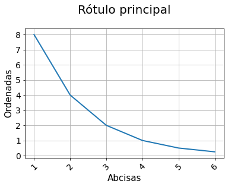

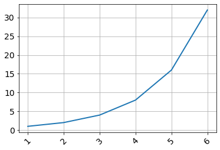

```python
# Pruebas de funcionamiento:

representar_xxx_yyy([(1, 8), (2, 4), (3, 2), (4, 1), (5, 0.5), (6, 0.25)], ["Rótulo principal", "Ordenadas", "Abcisas"])

representar_xxx_yyy([(1, 1), (2, 2), (3, 4), (4, 8), (5, 16), (6, 32)], [])
```

**d.2. Tasas de muerte por edades**

Queremos aplicar nuestro modelo de gráfica a la representación de las tasas de accidentes mortales por edad, que hemos calculado un poco antes. Pero obtenemos una gráfica poco adecuada, porque las edades (las abcisas) están en un orden arbitrario.

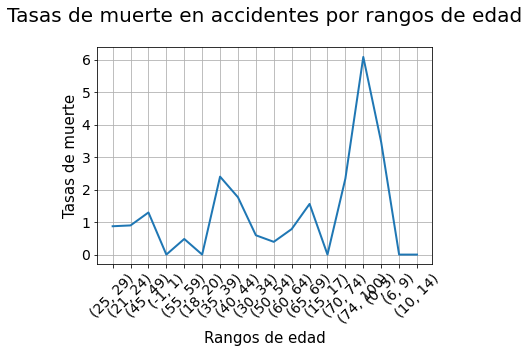

```python
# Intento de representación:

rotulos = "Tasas de muerte en accidentes por rangos de edad", "Tasas de muerte", "Rangos de edad"
representar_xxx_yyy(tasa_accidentes_mortales_por_mil, rotulos)
```

Para remediar esto se ha de reordenar la lista de pares absisa-ordenada, atendiendo a las abcisas. También, el elemento de abcisa (-1, -1) se ha de suprimir. Esto es lo que te pido.

```python
# Esta celda debe ser completada por el estudiante
def representar_xxx_yyy(lista, labels):
    """
    Given a list 'lista' of length 2 tuples, and the list labels;
    it returns a line plot where abscissa are the first values of the tuples and ordinates are the second values of the tuples
    In this case:
        the abscissas are sorted
        the range (-1,1) is removed
    The labels of the plot come from the labels list.

    Parameters
    ----------
    lista : list
        list of tuples, each tuple is one paired point abscissa and ordinate
    lables : list
        list of 3 strings:
        list[0] is the plot title
        list[1] is the vertical axis title
        list[2] is the horizontal axis title

    Return
    ------
    plot that represents each point

    Example
    -------
    >>> representar_xxx_yyy([(1, 8), (2, 4), (3, 2), (4, 1), (5, 0.5), (6, 0.25)], ["Rótulo principal", "Ordenadas", "Abcisas"])
    plot
    """
    import matplotlib.pyplot as plt
    lista.sort()
    lista = lista[1:]
    y = [lista[i][1] for i in range(len(lista))]
    x = [lista[i][0] for i in range(len(lista))]
    plt.plot(y, linewidth = 2)
    try:
        plt.title(labels[0], {'fontsize': 20}, pad = 25)
        plt.ylabel(labels[1],{'fontsize': 15})
        plt.xlabel(labels[2],{'fontsize': 15})
    except:
        pass
    plt.grid(True)
    plt.xticks([i for i in range(len(lista))], labels = x, rotation = 45, fontsize = 14)
    plt.yticks(fontsize = 14)
    return plt.show();
```

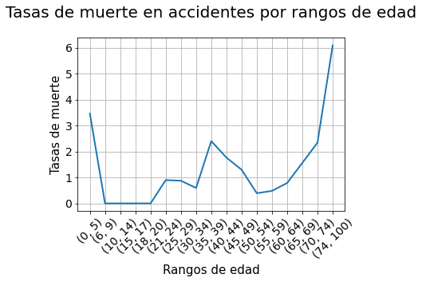

```python
# Prueba de funcionamiento:

representar_xxx_yyy(tasa_accidentes_mortales_por_mil, rotulos)
```

**d.3. Tasas de muerte por rangos horarios**

De forma similar a lo resuelto en los apartados anteriores, deseamos preparar los datos y un gráfico con la tasa de muerte por rangos horarios. En lugar de tratar los rangos por horas enteras (las 4 representa el intervalo entre las 4:00 y las 4:59), deseamos representar de dos en dos horas (las 4 representa el intervalo entre las 4:00 y las 5:59, las 6, entre las 6:00 y las 7:59, etc.)

Observa que se neesitan dos fuciones, una para recopilar los datos, calcular las tasas, dar una lista ordenada, etc., y otra para preparar las abcisas, cadenas de caracteres con las horas de dos en dos, junto con sus tasas respectivas.

```python
# Esta celda debe ser completada por el estudiante

def totales_mortales_por_horario(datos_lista):
    """
    given the list 'datos_lista' the function calculates the ratio of deaths per two hours.
    Function returns a list of length 2 tuples were the first element is the hour range(two hours),
    and the second element is the ratio.

    Parameters
    ----------
    datos_lista : list
        list of extracted lists from the csv file (see cell 17)

    Return
    ------
    list of tuples of two elements: hour range and ratio of deaths per two hours

    Example
    -------
    >>> totales_mortales_por_horario(datos_lista)
    [('(0,2)', 1.9230769230769231), ('(2,4)', 4.178272980501393), ('(4,6)', 1.949317738791423),
    ('(6,8)', 0.8635578583765112), ('(8,10)', 1.1415525114155252), ('(10,12)', 1.5337423312883436),
    ('(12,14)', 0.8234971177600878), ('(14,16)', 1.112099644128114), ('(16,18)', 0.5351886540005352),
    ('(18,20)', 0.4287245444801715), ('(20,22)', 1.1999040076793857), ('(22,24)', 1.187178472497032)]
    """
    contador = dict()
    for linea in datos_lista:
        contador[linea[0]] = contador.get(linea[0],0)+1

    contador = list(contador.items())
    contador.sort()

    mortalidad_hora = dict()
    for linea in datos_lista:
        mortalidad_hora[linea[0]] = mortalidad_hora.get(linea[0],0)
    for linea in datos_lista:
        if linea[4] == 4:
            mortalidad_hora[linea[0]]+=1

    mortalidad_hora = list(mortalidad_hora.items())
    mortalidad_hora.sort()

    mort_par = list()
    for i in range(int(len(mortalidad_hora)/2)):
        zero = i
        first = '({},{})'.format(2*i, 2*i+2)
        second = (mortalidad_hora[2*i][1]+mortalidad_hora[2*i+1][1])
        third = contador[2*i][1]+contador[2*i+1][1]
        element = [zero, first, second*1000/third]
        mort_par.append(element)
    mort_par.sort()
    for i in range(len(mort_par)):
        mort_par[i].pop(0)
        mort_par[i] = (mort_par[i][0], mort_par[i][1])
    return mort_par

def representar_xxx_yyy(lista, labels):
    """
    Given a list 'lista' of length 2 tuples, and the list labels;
    it returns a line plot where abscissa are the first values of the tuples and ordinates are the second values of the tuples
    In this case:
        the abscissas are sorted
        the range (-1,1) is removed
    The labels of the plot come from the labels list.

    Parameters
    ----------
    lista : list
        list of tuples, each tuple is one paired point abscissa and ordinate
    lables : list
        list of 3 strings:
        list[0] is the plot title
        list[1] is the vertical axis title
        list[2] is the horizontal axis title

    Return
    ------
    plot that represents each point

    Example
    -------
    >>> representar_xxx_yyy([(1, 8), (2, 4), (3, 2), (4, 1), (5, 0.5), (6, 0.25)], ["Rótulo principal", "Ordenadas", "Abcisas"])
    plot
    """
    import matplotlib.pyplot as plt
    y = [lista[i][1] for i in range(len(lista))]
    x = [lista[i][0] for i in range(len(lista))]
    plt.plot(y, linewidth = 2)
    try:
        plt.title(labels[0], {'fontsize': 20}, pad = 25)
        plt.ylabel(labels[1],{'fontsize': 15})
        plt.xlabel(labels[2],{'fontsize': 15})
    except:
        pass
    plt.grid(True)
    plt.xticks([i for i in range(len(lista))], labels = x, rotation = 45, fontsize = 14)
    plt.yticks(fontsize = 14)
    return plt.show();
```

[output not shown]

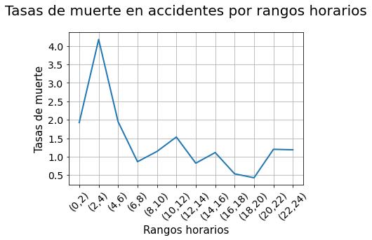

```python
# Prueba de funcionamiento:

tasas_accidentes_y_muertes_por_horario = totales_mortales_por_horario(datos_lista)
print(tasas_accidentes_y_muertes_por_horario)

rotulos = "Tasas de muerte en accidentes por rangos horarios", "Tasas de muerte", "Rangos horarios"
representar_xxx_yyy(tasas_accidentes_y_muertes_por_horario, rotulos)
```

# Prueba de funcionamiento:

tasas_accidentes_y_muertes_por_horario = totales_mortales_por_horario(datos_lista)

print(tasas_accidentes_y_muertes_por_horario)

print()

datos_para_grafica = emparejar_abcisas(tasas_accidentes_y_muertes_por_horario)

print(datos_para_grafica)

rotulos = "Tasas de muerte en accidentes por rangos horarios", "Tasas de muerte", "Rangos horarios" representar_xxx_yyy(datos_para_grafica, rotulos)

## e) Operaciones con dataframes [1.5 puntos]

En este apartado, vamos a trabajar con tablas de la librería `pandas`, llamadas `dataframes`.

**e1. Carga del dataframe.** La primera operación que necesitamos es cargar el archivo de datos en una tabla, como se ve en el siguiente ejemplo.

```python
# Esta celda debe ser completada por el estudiante
def cargar_dataframe_v0(filename):
    """
    given a file 'filename' function makes use of pandas to read and load a dataframe

    Parameters
    ----------
    filename : file
        csv file

    Return
    ------
    dataframe

    Example
    -------
    >>> tabla_pre = cargar_dataframe_v0("2020_Accidentalidad.csv")
    dataframe
    """
    import pandas as pd
    df = pd.read_csv(filename, sep = ';', encoding = 'ISO-8859-1')
    df = df[['HORA', 'DISTRITO', 'RANGO DE EDAD', 'LESIVIDAD*']]
    return df
```

```python
tabla_pre = cargar_dataframe_v0("2020_Accidentalidad.csv")
print(tabla_pre)
```

```
        HORA             DISTRITO    RANGO DE EDAD  LESIVIDAD*
0      23:15               RETIRO  DE 25 A 29 AÑOS         NaN
1      22:35      MONCLOA-ARAVACA  DE 21 A 24 AÑOS         6.0
2      20:15  FUENCARRAL-EL PARDO  DE 45 A 49 AÑOS        14.0
3      20:15  FUENCARRAL-EL PARDO  DE 25 A 29 AÑOS         7.0
4      19:45               CENTRO      DESCONOCIDA         NaN
...      ...                  ...              ...         ...
32415   0:18            CHAMARTÍN  DE 35 A 39 AÑOS         NaN
32416   0:18            CHAMARTÍN  DE 35 A 39 AÑOS         NaN
32417   0:18            CHAMARTÍN  DE 35 A 39 AÑOS         NaN
32418   0:18            CHAMARTÍN  DE 35 A 39 AÑOS         NaN
32419   0:18            CHAMARTÍN  DE 35 A 39 AÑOS         NaN

[32420 rows x 4 columns]
```

e2. Carga del dataframe, codificando rangos de edad y lesividad. Ahora, queremos modificar esta lectura para que los rangos de edad se conviertan en el intervalo correspondiente. Además, vemos que el nivel de lesividad se ha leído directamente como un real, y las cadenas en blanco se han traducido a NaN (Not a Number). Queremos ponerlo como un entero, consistente en un 1 cuando hay lesividad. Cuando no se conoce la lesividad, o no se conoce, consignaremos un 0.

```python
# Esta celda debe ser completada por el estudiante
def cargar_dataframe(filename):
    """
    Given a file 'filename' function returns a dataframe with the following fields:
        hour
        district
        age range (coded from the file string)
        harmfulness (coded as 1 when there is harm and 0 when there isn't harm or it is unknown)

    Parameters
    ----------
    filename : file
        csv from which the rows of the dataset are extracted

    Return
    ------
    dataframe with the following fields:
        hour
        district
        age range (coded from the file string)
        harmfulness (coded as 1 when there is harm and 0 when there isn't harm or it is unknown)

    Example
    -------
    >>> tabla = cargar_dataframe("2020_Accidentalidad.csv")
    dataframe
    """
    import pandas as pd
    tabla_pre = pd.read_csv(filename, sep = ';', encoding = 'ISO-8859-1')
    tabla_pre = tabla_pre[['HORA', 'DISTRITO', 'RANGO DE EDAD', 'LESIVIDAD*']]

    new_column = list()
    for i in tabla_pre['RANGO DE EDAD']:
        new_column.append(rango_edad(i))
    tabla_pre['RANGO DE EDAD'] = new_column

    tabla_pre['LESIVIDAD*'].fillna(0, inplace = True)
    tabla_pre['LESIVIDAD*'] = tabla_pre['LESIVIDAD*'].apply(lambda x: 1 if 1<=x<14 else 0)

    return tabla_pre
```

```python
tabla = cargar_dataframe("2020_Accidentalidad.csv")
tabla
```

|  | HORA | DISTRITO | RANGO DE EDAD | LESIVIDAD* |
| --- | --- | --- | --- | --- |
| 0 | 23:15 | RETIRO | (25, 29) | 0 |
| 1 | 22:35 | MONCLOA-ARAVACA | (21, 24) | 1 |
| 2 | 20:15 | FUENCARRAL-EL PARDO | (45, 49) | 0 |
| 3 | 20:15 | FUENCARRAL-EL PARDO | (25, 29) | 1 |
| 4 | 19:45 | CENTRO | (-1, 1) | 0 |
| ... | ... | ... | ... | ... |
| 32415 | 0:18 | CHAMARTÍN | (35, 39) | 0 |
| 32416 | 0:18 | CHAMARTÍN | (35, 39) | 0 |
| 32417 | 0:18 | CHAMARTÍN | (35, 39) | 0 |
| 32418 | 0:18 | CHAMARTÍN | (35, 39) | 0 |
| 32419 | 0:18 | CHAMARTÍN | (35, 39) | 0 |

32420 rows × 4 columns

**e3. Tabla de número de accidentes por rangos de edad**

Nos interesa quedarnos únicamente con dos columnas: el rango de edad y el número de accidentes, formando una tabla nueva. Esta tabla debe mostrarse en orden ascendente de rango de edad.

```python
# Esta celda debe ser completada por el estudiante
num_accs = tabla.groupby('RANGO DE EDAD', as_index = False, sort = True).count().iloc[:,[0,2]].rename(
    columns = {'RANGO DE EDAD':'Edad', 'DISTRITO':'NumAccs'})
num_accs
```

|  | Edad | NumAccs |
| --- | --- | --- |
| 0 | (-1, 1) | 3962 |
| 1 | (0, 5) | 289 |
| 2 | (6, 9) | 175 |
| 3 | (10, 14) | 305 |
| 4 | (15, 17) | 250 |
| 5 | (18, 20) | 978 |
| 6 | (21, 24) | 2226 |
| 7 | (25, 29) | 3437 |
| 8 | (30, 34) | 3362 |
| 9 | (35, 39) | 3332 |
| 10 | (40, 44) | 3399 |
| 11 | (45, 49) | 3084 |
| 12 | (50, 54) | 2545 |
| 13 | (55, 59) | 2077 |
| 14 | (60, 64) | 1272 |
| 15 | (65, 69) | 641 |
| 16 | (70, 74) | 427 |
| 17 | (74, 100) | 657 |

Esta tabla contiene el rango de edad $(-1, -1)$, que no nos interesa. Por eso preferimos descartar esta fila.

```python
# Esta celda debe ser completada por el estudiante
num_accs = tabla.groupby('RANGO DE EDAD', as_index = False, sort = True).count().iloc[:,[0,2]].rename(
    columns = {'RANGO DE EDAD':'Edad', 'DISTRITO':'NumAccs'}).drop([0])
num_accs
```

|  | Edad | NumAccs |
| --- | --- | --- |
| 1 | (0, 5) | 289 |
| 2 | (6, 9) | 175 |
| 3 | (10, 14) | 305 |
| 4 | (15, 17) | 250 |
| 5 | (18, 20) | 978 |
| 6 | (21, 24) | 2226 |
| 7 | (25, 29) | 3437 |
| 8 | (30, 34) | 3362 |
| 9 | (35, 39) | 3332 |
| 10 | (40, 44) | 3399 |
| 11 | (45, 49) | 3084 |
| 12 | (50, 54) | 2545 |
| 13 | (55, 59) | 2077 |
| 14 | (60, 64) | 1272 |
| 15 | (65, 69) | 641 |
| 16 | (70, 74) | 427 |
| 17 | (74, 100) | 657 |

**e4. Accidentes con consecuencias médicas.**

Queremos totalizar ahora los accidentes que requieren algún tipo de atención sanitaria o con resultado de muerte por cada rango de edad.

```python
# Esta celda debe ser completada por el estudiante
num_accs_les = tabla[tabla['LESIVIDAD*']==1].groupby('RANGO DE EDAD', as_index = False, sort = True).count().iloc[:,[0,2]].rename(
    columns = {'RANGO DE EDAD':'Edad', 'DISTRITO':'NumAccsConLesiones'}).drop([0])
num_accs_les
```

|  | Edad | NumAccsConLesiones |
| --- | --- | --- |
| 1 | (0, 5) | 107 |
| 2 | (6, 9) | 73 |
| 3 | (10, 14) | 135 |
| 4 | (15, 17) | 114 |
| 5 | (18, 20) | 325 |
| 6 | (21, 24) | 720 |
| 7 | (25, 29) | 1184 |
| 8 | (30, 34) | 1098 |
| 9 | (35, 39) | 944 |
| 10 | (40, 44) | 899 |
| 11 | (45, 49) | 735 |
| 12 | (50, 54) | 586 |
| 13 | (55, 59) | 493 |
| 14 | (60, 64) | 281 |
| 15 | (65, 69) | 153 |
| 16 | (70, 74) | 129 |
| 17 | (74, 100) | 260 |

**e4. Unión de dos tablas.**

Deseamos ahora combinar las dos tablas generadas, usando la columna "Edad" como pivote, al estilo de la operación `inner join` de SQL en el mundo de las bases de datos.

```python
# Esta celda debe ser completada por el estudiante
import pandas as pd
join = pd.merge(num_accs, num_accs_les, how = 'inner', on = 'Edad')
join
```

|  | Edad | NumAccs | NumAccsConLesiones |
| --- | --- | --- | --- |
| 0 | (0, 5) | 289 | 107 |
| 1 | (6, 9) | 175 | 73 |
| 2 | (10, 14) | 305 | 135 |
| 3 | (15, 17) | 250 | 114 |
| 4 | (18, 20) | 978 | 325 |
| 5 | (21, 24) | 2226 | 720 |
| 6 | (25, 29) | 3437 | 1184 |
| 7 | (30, 34) | 3362 | 1098 |
| 8 | (35, 39) | 3332 | 944 |
| 9 | (40, 44) | 3399 | 899 |
| 10 | (45, 49) | 3084 | 735 |
| 11 | (50, 54) | 2545 | 586 |
| 12 | (55, 59) | 2077 | 493 |
| 13 | (60, 64) | 1272 | 281 |
| 14 | (65, 69) | 641 | 153 |
| 15 | (70, 74) | 427 | 129 |
| 16 | (74, 100) | 657 | 260 |

**e5. Proporción de accidentes con lesiones.**

Deseamos ahora combinar las dos tablas generadas, usando la columna "Edad" como pivote, al estilo de la operación `inner join` de SQL en el mundo de las bases de datos.

```python
# Esta celda debe ser completada por el estudiante
join['PropLesiones'] = join['NumAccsConLesiones']/join['NumAccs']
join
```

|  | Edad | NumAccs | NumAccsConLesiones | PropLesiones |
| --- | --- | --- | --- | --- |
| 0 | (0, 5) | 289 | 107 | 0.370242 |
| 1 | (6, 9) | 175 | 73 | 0.417143 |
| 2 | (10, 14) | 305 | 135 | 0.442623 |
| 3 | (15, 17) | 250 | 114 | 0.456000 |
| 4 | (18, 20) | 978 | 325 | 0.332311 |
| 5 | (21, 24) | 2226 | 720 | 0.323450 |
| 6 | (25, 29) | 3437 | 1184 | 0.344486 |
| 7 | (30, 34) | 3362 | 1098 | 0.326591 |
| 8 | (35, 39) | 3332 | 944 | 0.283313 |
| 9 | (40, 44) | 3399 | 899 | 0.264490 |
| 10 | (45, 49) | 3084 | 735 | 0.238327 |
| 11 | (50, 54) | 2545 | 586 | 0.230255 |
| 12 | (55, 59) | 2077 | 493 | 0.237362 |
| 13 | (60, 64) | 1272 | 281 | 0.220912 |
| 14 | (65, 69) | 641 | 153 | 0.238690 |
| 15 | (70, 74) | 427 | 129 | 0.302108 |
| 16 | (74, 100) | 657 | 260 | 0.395738 |

**e6. Gráfico.**

Finalmente, deseamos presentar la proporción de accidentes con lesiones por edades, por si al ver esto pudiéramos extraer alguna conclusión útil.

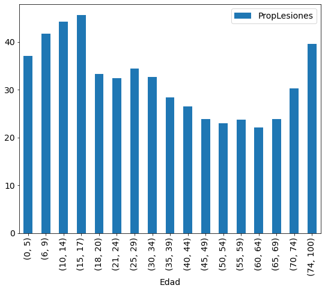

```python
# Esta celda debe ser completada por el estudiante
import matplotlib.pyplot as plt

join['PropLesiones'] = join['PropLesiones']*100
join.plot.bar('Edad', 'PropLesiones', figsize = (9,7), fontsize = 14);

plt.xlabel('Edad', fontsize = 14)
plt.legend(fontsize = 14);
```

## f) Un cálculo masivo con map-reduce [0.5 puntos]

```
C:\...> python total_accs_edad.py -q 2020_Accidentalidad.csv
```

El programa funcionará necesariamente con la técnica map-reduce, que podemos poner en juego con la librería `mrjob`.

El funcionamiento del mismo se puede activar también desde aquí:

```python
# Hagamos una llamada al programa de consola desde aquí:

# Como referencia se coloca en forma de comentario el programa que corre en la consola

#def rango_edad(rangos_edad):
#    import re
#    buscar = '\d+'
#    a = re.findall(buscar, rangos_edad)
#    try:
#        intervalo = (int(a[0]), int(a[1]))
#    except:
#        try:
#            intervalo = (int(a[0]), 100)
#        except:
#            intervalo = (-1, 1)
#    return intervalo
#
#class counter(MRJob):
#
#    def mapper(self, _, row):
#        rango = rango_edad(row.split(";")[10])
#        mortalidad = row.split(";")[12]
#        try:
#            mortalidad = int(mortalidad)
#        except:
#            pass
#        if rango != (-1,1):
#            if mortalidad == 4:
#                yield rango, [1,1]
#            else:
#                yield rango, [1,0]
#
#    def reducer(self, key, values):
#        accidentes,mortalidad = zip(*values)
#        yield (key, [sum(accidentes), sum(mortalidad)])
#
#if __name__ == '__main__':
#    counter.run()

! python total_accs_edad.py -q 2020_Accidentalidad.csv
```

```
[0,5]	[289,1]
[10,14]	[305,0]
[15,17]	[250,0]
[18,20]	[978,0]
[21,24]	[2226,2]
[25,29]	[3437,3]
[30,34]	[3362,2]
[35,39]	[3332,8]
[40,44]	[3399,6]
[45,49]	[3084,4]
[50,54]	[2547,1]
[55,59]	[2077,1]
[6,9]	[175,0]
[60,64]	[1272,1]
[65,69]	[641,1]
[70,74]	[427,1]
[74,100]	[657,4]
```

```python
# Hagamos una llamada al programa de consola desde aquí:

! python total_accs_edad.py -q 2020_Accidentalidad.csv
```

```
[0,5]	[289,1]
[10,14]	[305,0]
[15,17]	[250,0]
[18,20]	[978,0]
[21,24]	[2226,2]
[25,29]	[3437,3]
[30,34]	[3362,2]
[35,39]	[3332,8]
[40,44]	[3399,6]
[45,49]	[3084,4]
[50,54]	[2547,1]
[55,59]	[2077,1]
[6,9]	[175,0]
[60,64]	[1272,1]
[65,69]	[641,1]
[70,74]	[427,1]
[74,100]	[657,4]
```

```python
# Para que el resultado se almacene en un archivo:

! python total_accs_edad.py -q 2020_Accidentalidad.csv  > accidentalidad_y_mortalidad_por_edades.txt
```

Para que pueda yo ver tu programa cómodamente desde aquí, también se puede mostrar con un comando de la consola, anteponiendo el símbolo `!`.

**Notas.** 1) La instrucción siguiente está comentada para ocultar una solución mía. 2) Desde mac o linux, se ha de usar el comando `cat`, en vez de `type`.

```python
#! type total_accs_edad.py
```

## g) Un apartado libre [0.5 puntos]

Dejo este apartado a tu voluntad. Inventa tú mismo el enunciado y resuélvelo, mostrando algún aspecto de programación en Python no contemplado o alguna técnica o librería que no has puesto en juego en los apartados anterioresc, relacionado con el análisis de datos o con este proyecto. He aquí dos ejemplos posibles:

- Me he quedado un poco insatisfecho con el uso de pandas, un poco escaso: este apartado adicional podría usar dicha librería poniendo en juego algunas operaciones que no hemos visto.
- Tampoco me gusta mucho el acabado de las figuras: la librería Plotly puede ser quizá permitirte trazar figuras más profesionales, y una posibilidad sencilla es quizá importar los datos del archivo creado por el programa de map-reduce y representarlos gráficamente.

Estos ejemplos pueden servirte como pista, pero que no te limiten: puedes proponer tú algo que te parezca oportuno, para mostrar algún aspecto que no se cubra bien en los apartados anteriores, relacionado con el análisis de datos o con este proyecto pero o para practicar con una librería que te parezca interesante.

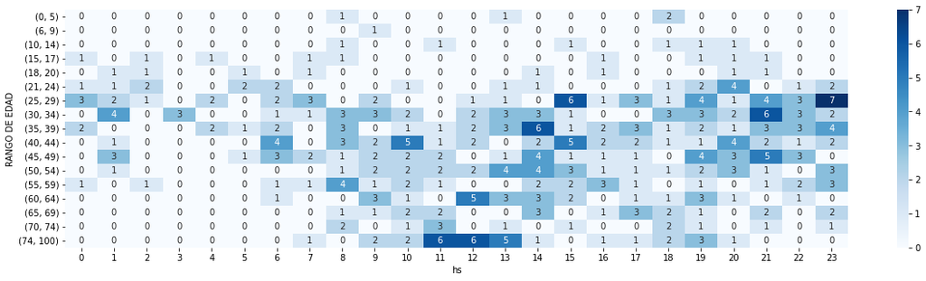

```python
# Este apartado debe ser completado por el estudiante

#Utilizar la librería seaborn para realizar un heatmap en donde se muestre:
#los accidents graves y mortales por rango de edad y hora del día.

import pandas as pd
import numpy as np
import seaborn as sb
tabla = pd.read_csv("2020_Accidentalidad.csv", sep = ';', encoding = 'ISO-8859-1')
tabla = tabla[['HORA', 'DISTRITO', 'RANGO DE EDAD', 'LESIVIDAD*']]

new_column = list()
for i in tabla['RANGO DE EDAD']:
    new_column.append(rango_edad(i))
tabla['RANGO DE EDAD'] = new_column
tabla['hs'] = tabla['HORA'].str.split(':', expand = True)[0]
replace = {1:'leve', 2:'leve', 3:'grave', 4:'mortal', 5:'leve', 6:'leve', 7:'leve', 14:'sin asistencia'}
tabla.fillna(14, inplace = True)
tabla['LESIVIDAD'] = tabla['LESIVIDAD*'].replace(replace)

htm = tabla[['RANGO DE EDAD', 'hs', 'LESIVIDAD']].query('LESIVIDAD =="grave"'
                                                  or 'LESIVIDAD =="mortal"').groupby(['RANGO DE EDAD', 'hs']).size()
htm = htm.reset_index()
htm = pd.pivot(data = htm, index = 'RANGO DE EDAD', columns = 'hs', values = 0)
hs = list(np.arange(0,24))
hs = [str(i) for i in hs]
htm = htm[hs]
htm.fillna(0, inplace = True)
plt.figure(figsize = (20,5))
sb.heatmap(data = htm, annot = True, vmin = 0, cmap = 'Blues', fmt = '.0f');
```

### Datos personales

- **Apellidos:** Ianchina Raed
- **Nombre:** José Agustín
- **Email:** agustinianchina@outlook.com
- **Fecha:** Enero 25, 2022

### Ficha de autoevaluación

**Comentarios sobre la autoevaluación**: ............. comentarios del estudiante.

| Apartado | Calificación | Comentario |
| --- | --- | --- |
| a) | 1.75 / 2.0 | El código corre completo y se obtiene el resultado deseado. Puede haber errores en cuanto al estilo y documentación de la función, ya que es contenido con el cual no me siento tan seguro aún. |
| b) | 1.75 / 2.0 | El código corre completo y se obtiene el resultado deseado. Puede haber errores en cuanto al estilo y documentación de la función, ya que es contenido con el cual no me siento tan seguro aún. |
| c) | 1.75 / 2.0 | El código corre completo y se obtiene el resultado deseado. Puede haber errores en cuanto al estilo y documentación de la función, ya que es contenido con el cual no me siento tan seguro aún. |
| d) | 1.25 / 1.5 | El código corre completo y se obtiene el resultado deseado. Puede haber errores en cuanto al estilo y documentación de la función, ya que es contenido con el cual no me siento tan seguro aún. |
| e) | 1.25 / 1.5 | El código corre completo y se obtiene el resultado deseado. Puede haber errores en cuanto al estilo y documentación de la función, ya que es contenido con el cual no me siento tan seguro aún. |
| f) | 0.25 / 0.5 | El código corre completo y se obtiene el resultado deseado. Puede haber errores en cuanto al estilo y documentación de la función, ya que es contenido con el cual no me siento tan seguro aún. |
| g) | 0.25 / 0.5 | El código corre completo y se obtiene el resultado deseado. Puede haber errores en cuanto al estilo y documentación de la función, ya que es contenido con el cual no me siento tan seguro aún. |
| **Total** | **8.25** / 10.0 | **Entregar** |

### Ayuda recibida y fuentes utilizadas

Además de los recursos propios del módulo, se trabajó consultando las siguientes páginas

https://stackoverflow.com/  
https://www.geeksforgeeks.org/  
https://pandas.pydata.org/  
https://www.learnpython.org/en/Map%2C_Filter%2C_Reduce  
https://nbanzyme.medium.com/python-map-filter-zip-and-reduce-by-examples-aa8f7605d0d6

### Comentario adicional

Las premisas de trabajo han sido:

1. Respetar lo máximo posible la estructura del archivo provisto
2. Cumplir lo más precisamente posible el test propuesto para cada ejercicio
3. Me he enfocado mucho en que el código corriera completo y obtener los resultados deseados
4. Quizás he descuidado el estilo y la documentación de las funciones.  
   Esto último trate de hacerlo respetando el std.(inglés y con los lineamientos que se dieron en los videos y la documentación) ..................... Este apartado es optativo .....................

```python
# Esta celda se ha de respetar: está aquí para comprobar el funcionamiento de algunas funciones por parte de tu profesor
```